# GGplot2 in R Assignment

Quynh Nhu Nguyen

2023-03-26

# **GGPLOT2 IN R ASSIGNMENT**

```r
# Load library
library(tidyverse)
library(data.table)
library(factoextra) # Package for calculation PCA
```

```r
library(ComplexHeatmap)
library(circlize) # Package of Color for heatmap visualization
library(reshape) # reshape a data frame to 'wide' format
```

## 1. DATA “DNA METHYLATION”

### Prepare data

#### Method 1:

```r
# Set the working directory to the folder containing the TSV files
setwd("C:/Users/lucia/Downloads/Lecturer from Dr. Loi/NGS3/NGS3-W9-19-03-2023/Data/Basic R5_ ggplot2 package/DNAmethylation")
getwd()
```

```
## [1] "C:/Users/lucia/Downloads/Lecturer from Dr. Loi/NGS3/NGS3-W9-19-03-2023/Data/Basic R5_ ggplot2 package/DNAmethylation"
```

```r
# Load data
tsv_files <- list.files(pattern = "\\.tsv$") # List all the TSV files in the folder
combined_data <- data.frame() # Create an empty data frame to store the combined data

# Loop through each TSV file, read it in as a data frame, and add it to the combined data
for (file in tsv_files) {
  data <- read_tsv(file)
  data_combine <- bind_rows(combined_data, data)
}
write_tsv(data_combine, "combined_data.tsv") # Write the combined data to a new TSV file
```

#### Method 2:

```r
# List all the TSV files in the folder
filename1 <- list.files("C:/Users/lucia/Downloads/Lecturer from Dr. Loi/NGS3/NGS3-W9-19-03-2023/Data/Basic R5_ ggplot2 package/DNAmethylation", pattern = '\\.tsv$', full.names = TRUE)

# Read all files
data_f <- lapply(filename1, function(x) read.table(x,header=T))

# Merge all files using do.call
data_combine <- do.call("rbind", data_f )
```

```r
# Check data
data_combine <- data_combine[, c(14, 1:13)] # Move the "subtype" column to 1st column
head(data_combine)
```

```
##   subtype cg01796223 cg01091565 cg04705866 cg11484872 cg26607785 cg03409548
## 1      FA       0.82       0.87       0.87       0.72       0.19       0.19
## 2   NIFTP       0.35       0.50       0.50       0.39       0.15       0.47
## 3      FA       0.82       0.83       0.83       0.72       0.16       0.28
## 4      FA       0.62       0.81       0.82       0.72       0.14       0.18
## 5      FC       0.53       0.79       0.85       0.66       0.44       0.16
## 6      FC       0.86       0.87       0.83       0.69       0.38       0.25
##   cg06454226 cg03001305 cg19282250 cg15639951 cg02192520 cg08675585 cg07447773
## 1       0.32       0.65       0.52       0.62       0.73       0.89       0.53
## 2       0.33       0.08       0.44       0.25       0.67       0.53       0.27
## 3       0.19       0.63       0.79       0.66       0.85       0.87       0.76
## 4       0.21       0.17       0.47       0.34       0.32       0.86       0.49
## 5       0.33       0.13       0.74       0.41       0.60       0.85       0.51
## 6       0.17       0.63       0.54       0.64       0.82       0.80       0.74
```

```r
dim(data_combine)
```

```
## [1] 73 14
```

```r
str(data_combine)
```

```
## 'data.frame':    73 obs. of  14 variables:
##  $ subtype   : chr  "FA" "NIFTP" "FA" "FA" ...
##  $ cg01796223: num  0.82 0.35 0.82 0.62 0.53 0.86 0.32 0.3 0.52 0.3 ...
##  $ cg01091565: num  0.87 0.5 0.83 0.81 0.79 0.87 0.82 0.83 0.85 0.83 ...
##  $ cg04705866: num  0.87 0.5 0.83 0.82 0.85 0.83 0.83 0.86 0.86 0.83 ...
##  $ cg11484872: num  0.72 0.39 0.72 0.72 0.66 0.69 0.65 0.74 0.75 0.68 ...
##  $ cg26607785: num  0.19 0.15 0.16 0.14 0.44 0.38 0.37 0.47 0.41 0.17 ...
##  $ cg03409548: num  0.19 0.47 0.28 0.18 0.16 0.25 0.18 0.21 0.15 0.13 ...
##  $ cg06454226: num  0.32 0.33 0.19 0.21 0.33 0.17 0.51 0.25 0.44 0.73 ...
##  $ cg03001305: num  0.65 0.08 0.63 0.17 0.13 0.63 0.44 0.52 0.21 0.15 ...
##  $ cg19282250: num  0.52 0.44 0.79 0.47 0.74 0.54 0.73 0.76 0.69 0.76 ...
##  $ cg15639951: num  0.62 0.25 0.66 0.34 0.41 0.64 0.62 0.44 0.38 0.49 ...
##  $ cg02192520: num  0.73 0.67 0.85 0.32 0.6 0.82 0.75 0.77 0.79 0.7 ...
##  $ cg08675585: num  0.89 0.53 0.87 0.86 0.85 0.8 0.79 0.83 0.85 0.82 ...
##  $ cg07447773: num  0.53 0.27 0.76 0.49 0.51 0.74 0.67 0.32 0.55 0.79 ...
```

```r
# Check and remove NA
colSums(is.na(data_combine))
```

```
##    subtype cg01796223 cg01091565 cg04705866 cg11484872 cg26607785 cg03409548
##          0          0          0          0          0          0          0
## cg06454226 cg03001305 cg19282250 cg15639951 cg02192520 cg08675585 cg07447773
##          0          0          0          0          0          0          0
```

```r
data_rm <- na.omit(data_combine)
head(data_combine)
```

```
##   subtype cg01796223 cg01091565 cg04705866 cg11484872 cg26607785 cg03409548
## 1      FA       0.82       0.87       0.87       0.72       0.19       0.19
## 2   NIFTP       0.35       0.50       0.50       0.39       0.15       0.47
## 3      FA       0.82       0.83       0.83       0.72       0.16       0.28
## 4      FA       0.62       0.81       0.82       0.72       0.14       0.18
## 5      FC       0.53       0.79       0.85       0.66       0.44       0.16
## 6      FC       0.86       0.87       0.83       0.69       0.38       0.25
##   cg06454226 cg03001305 cg19282250 cg15639951 cg02192520 cg08675585 cg07447773
## 1       0.32       0.65       0.52       0.62       0.73       0.89       0.53
## 2       0.33       0.08       0.44       0.25       0.67       0.53       0.27
## 3       0.19       0.63       0.79       0.66       0.85       0.87       0.76
## 4       0.21       0.17       0.47       0.34       0.32       0.86       0.49
## 5       0.33       0.13       0.74       0.41       0.60       0.85       0.51
## 6       0.17       0.63       0.54       0.64       0.82       0.80       0.74
```

### 1.1 Plot PCA following subtypes

```r
# Numeric data
number_data <- data_rm[,2:14]
head(number_data)
```

```
##   cg01796223 cg01091565 cg04705866 cg11484872 cg26607785 cg03409548 cg06454226
## 1       0.82       0.87       0.87       0.72       0.19       0.19       0.32
## 2       0.35       0.50       0.50       0.39       0.15       0.47       0.33
## 3       0.82       0.83       0.83       0.72       0.16       0.28       0.19
## 4       0.62       0.81       0.82       0.72       0.14       0.18       0.21
## 5       0.53       0.79       0.85       0.66       0.44       0.16       0.33
## 6       0.86       0.87       0.83       0.69       0.38       0.25       0.17
##   cg03001305 cg19282250 cg15639951 cg02192520 cg08675585 cg07447773
## 1       0.65       0.52       0.62       0.73       0.89       0.53
## 2       0.08       0.44       0.25       0.67       0.53       0.27
## 3       0.63       0.79       0.66       0.85       0.87       0.76
## 4       0.17       0.47       0.34       0.32       0.86       0.49
## 5       0.13       0.74       0.41       0.60       0.85       0.51
## 6       0.63       0.54       0.64       0.82       0.80       0.74
```

```r
str(number_data)
```

```
## 'data.frame':    73 obs. of  13 variables:
##  $ cg01796223: num  0.82 0.35 0.82 0.62 0.53 0.86 0.32 0.3 0.52 0.3 ...
##  $ cg01091565: num  0.87 0.5 0.83 0.81 0.79 0.87 0.82 0.83 0.85 0.83 ...
##  $ cg04705866: num  0.87 0.5 0.83 0.82 0.85 0.83 0.83 0.86 0.86 0.83 ...
##  $ cg11484872: num  0.72 0.39 0.72 0.72 0.66 0.69 0.65 0.74 0.75 0.68 ...
##  $ cg26607785: num  0.19 0.15 0.16 0.14 0.44 0.38 0.37 0.47 0.41 0.17 ...
##  $ cg03409548: num  0.19 0.47 0.28 0.18 0.16 0.25 0.18 0.21 0.15 0.13 ...
##  $ cg06454226: num  0.32 0.33 0.19 0.21 0.33 0.17 0.51 0.25 0.44 0.73 ...
##  $ cg03001305: num  0.65 0.08 0.63 0.17 0.13 0.63 0.44 0.52 0.21 0.15 ...
##  $ cg19282250: num  0.52 0.44 0.79 0.47 0.74 0.54 0.73 0.76 0.69 0.76 ...
##  $ cg15639951: num  0.62 0.25 0.66 0.34 0.41 0.64 0.62 0.44 0.38 0.49 ...
##  $ cg02192520: num  0.73 0.67 0.85 0.32 0.6 0.82 0.75 0.77 0.79 0.7 ...
##  $ cg08675585: num  0.89 0.53 0.87 0.86 0.85 0.8 0.79 0.83 0.85 0.82 ...
##  $ cg07447773: num  0.53 0.27 0.76 0.49 0.51 0.74 0.67 0.32 0.55 0.79 ...
```

```r
### Normalise data
colMeans(number_data)
```

```
## cg01796223 cg01091565 cg04705866 cg11484872 cg26607785 cg03409548 cg06454226
##  0.5500000  0.8563014  0.8526027  0.7098630  0.2569863  0.1489041  0.3406849
## cg03001305 cg19282250 cg15639951 cg02192520 cg08675585 cg07447773
##  0.3734247  0.6447945  0.5298630  0.6757534  0.8176712  0.6052055
```

```r
data_normalized <- scale(number_data)
colMeans(data_normalized)
```

```
##    cg01796223    cg01091565    cg04705866    cg11484872    cg26607785
## -2.190029e-16 -5.626207e-16 -1.872551e-16 -2.305044e-17  9.990106e-17
##    cg03409548    cg06454226    cg03001305    cg19282250    cg15639951
## -4.063530e-17  6.290155e-17 -2.870611e-17  2.175771e-16  2.180702e-16
##    cg02192520    cg08675585    cg07447773
## -2.451426e-16  5.670407e-16 -1.932434e-16
```

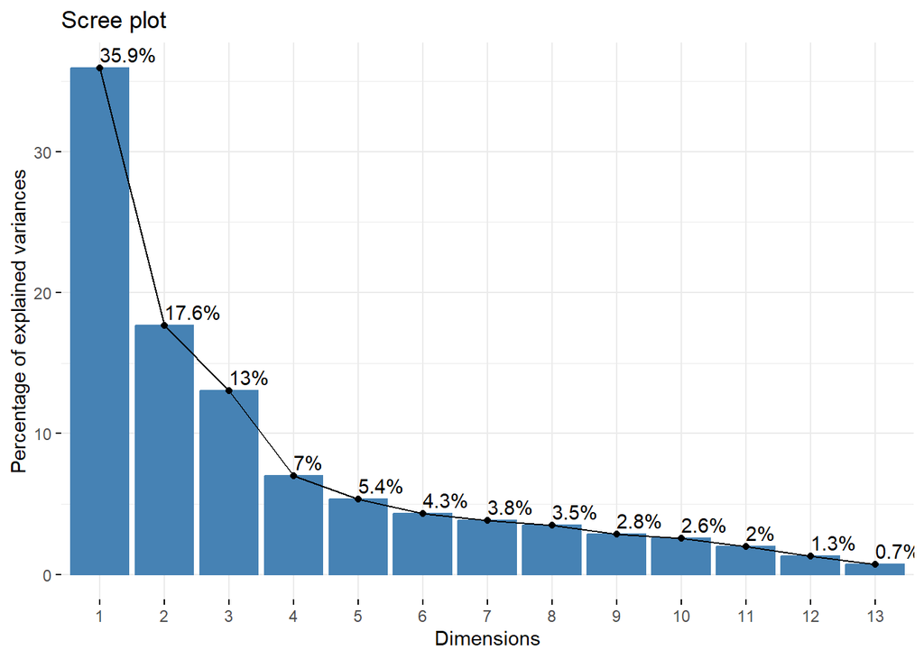

```r
# Caculate PCA
Xpca <- prcomp(data_normalized)
fviz_eig(Xpca,addlabels=TRUE, ncp=20)
```

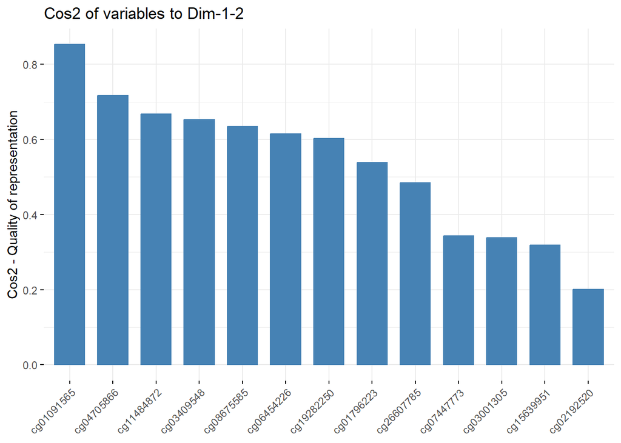

```r
fviz_cos2(Xpca, choice = "var", axes = 1:2)
```

```r
# Draw PCA
data_PCA <- as.data.frame(Xpca$x)
head(data_PCA)
```

```
##          PC1        PC2        PC3        PC4         PC5         PC6
## 1 -0.7526091  1.7551147 -0.9153785  0.5454414  0.14102559  0.56557029
## 2  9.0421500 -0.3103891 -2.1869154  0.8450863 -0.01653217  0.31482378
## 3 -0.4224180  0.9935154 -1.6740261 -0.7372414 -1.43472285  1.44584981
## 4  1.4556463  1.4746914  1.8334692  0.2666994 -0.24784938  0.26684822
## 5  0.7573904 -0.9758543  0.6629952  0.9049880 -1.20046007 -0.04601236
## 6 -0.2210678  1.1472347 -2.0673531 -0.2214896 -0.97171572  0.74978572
##          PC7         PC8        PC9       PC10       PC11        PC12
## 1  0.0156126  0.04414076  0.7931623 -0.1372939 -0.2425458  0.26389590
## 2  0.2434645  0.36111418 -0.2549837  0.1524367 -0.6485066 -0.04992645
## 3  0.7256884 -0.78272515  0.5445162 -0.1652135 -0.4543455 -0.14616355
## 4 -0.4909576  0.18062574  0.2119299 -0.1489358 -0.4802718  0.60317624
## 5 -0.1782051  0.58201331  0.1024079 -0.2896794  0.2473817  0.07849282
## 6 -1.1363577 -0.20766666  0.0506107 -0.2561400  0.3891901  0.24871234
##          PC13
## 1  0.04826336
## 2  0.27467396
## 3  0.33362132
## 4 -0.08089561
## 5 -0.58020052
## 6  0.57035521
```

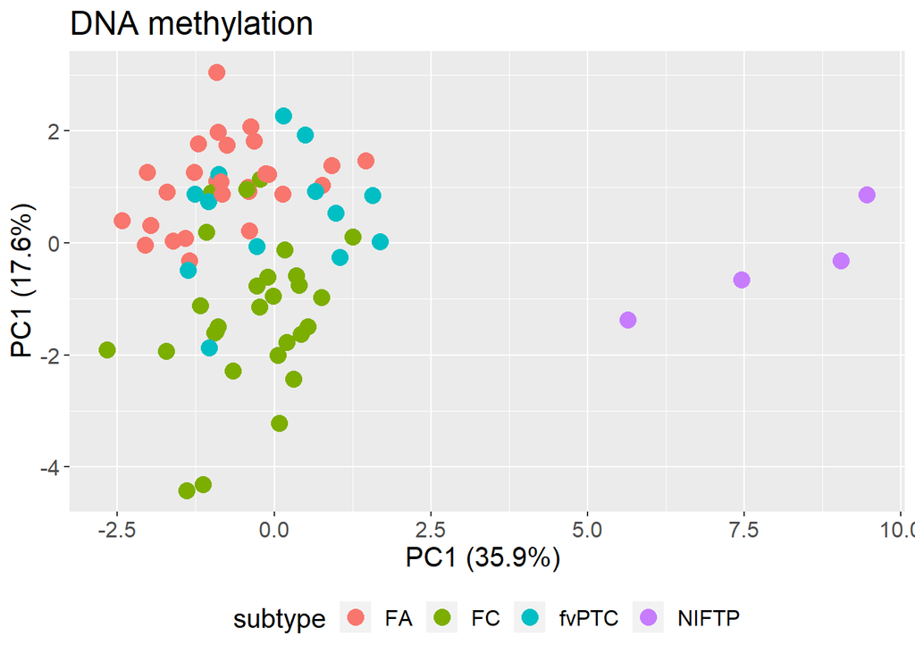

```r
data_PCA$subtype <- data_rm$subtype
ggplot(data_PCA, aes(x = PC1, y = PC2, col=subtype)) + geom_point(size=4, alpha=2) +
  theme(legend.position="bottom") + theme(text = element_text(size = 15))+
  labs(x="PC1 (35.9%) ", y="PC1 (17.6%)", title="DNA methylation")
```

### 1.2 Plot heatmap between four subtypes FA, FC, NIFTP and fv

```r
# Convert the "subtype" column to a factor
data_rm$subtype <- as.factor(data_rm$subtype)
```

The `aggregate()` function is used to calculate the mean of each column in the data frame for each level of the “x” factor variable. The `by` argument is set to `List(df[, 1])` to indicate that the means should be calculated for each level of the factor variable, which is the first column of the data frame. The `FUN` argument is set to mean to indicate that the mean should be calculated for each column. Note that `aggregate()` only works with numeric columns, so any non-numeric columns will be ignored. If your data frame contains missing values (NAs), you may want to use the `na.rm` argument of `mean()` to exclude missing values from the calculation.

```r
# Calculate the mean of each column for each level of the factor variable
means <- aggregate(data_rm[, 2:14], by = list(data_rm[, 1]), FUN = mean)
head(means)
```

```
##   Group.1 cg01796223 cg01091565 cg04705866 cg11484872 cg26607785 cg03409548
## 1      FA  0.7035714  0.8742857  0.8617857  0.7507143  0.2275000  0.1382143
## 2      FC  0.4482143  0.8725000  0.8642857  0.7089286  0.3467857  0.1303571
## 3   fvPTC  0.5269231  0.8838462  0.8884615  0.7130769  0.1676923  0.1284615
## 4   NIFTP  0.2625000  0.5275000  0.5900000  0.4200000  0.1250000  0.4200000
##   cg06454226 cg03001305 cg19282250 cg15639951 cg02192520 cg08675585 cg07447773
## 1  0.2703571  0.5050000  0.5939286  0.6417857  0.7385714  0.8453571  0.5714286
## 2  0.4335714  0.3103571  0.7335714  0.5021429  0.7250000  0.8132143  0.6939286
## 3  0.3192308  0.3053846  0.6046154  0.4261538  0.4753846  0.8438462  0.5423077
## 4  0.2525000  0.1150000  0.5100000  0.2775000  0.5425000  0.5700000  0.4250000
```

```r
str(means)
```

```
## 'data.frame':    4 obs. of  14 variables:
##  $ Group.1   : Factor w/ 4 levels "FA","FC","fvPTC",..: 1 2 3 4
##  $ cg01796223: num  0.704 0.448 0.527 0.263
##  $ cg01091565: num  0.874 0.873 0.884 0.527
##  $ cg04705866: num  0.862 0.864 0.888 0.59
##  $ cg11484872: num  0.751 0.709 0.713 0.42
##  $ cg26607785: num  0.228 0.347 0.168 0.125
##  $ cg03409548: num  0.138 0.13 0.128 0.42
##  $ cg06454226: num  0.27 0.434 0.319 0.252
##  $ cg03001305: num  0.505 0.31 0.305 0.115
##  $ cg19282250: num  0.594 0.734 0.605 0.51
##  $ cg15639951: num  0.642 0.502 0.426 0.277
##  $ cg02192520: num  0.739 0.725 0.475 0.542
##  $ cg08675585: num  0.845 0.813 0.844 0.57
##  $ cg07447773: num  0.571 0.694 0.542 0.425
```

The `t()` function is used to transpose the data frame, so that the rows become columns and the columns become rows. The `[, -1]` indexing syntax is used to exclude the first column, which is assumed to be the row labels.

```r
# Transpose the data frame from rows become columns
means1 <- t(means[, -1])
colnames(means1) <- means[, 1] # Names of "4 subtypes" are names of columns in new data-frame
```

```r
# Convert a data frame to a matrix
class(means1)
```

```
## [1] "matrix" "array"
```

```r
mat <- as.matrix(means1)
class(mat)
```

```
## [1] "matrix" "array"
```

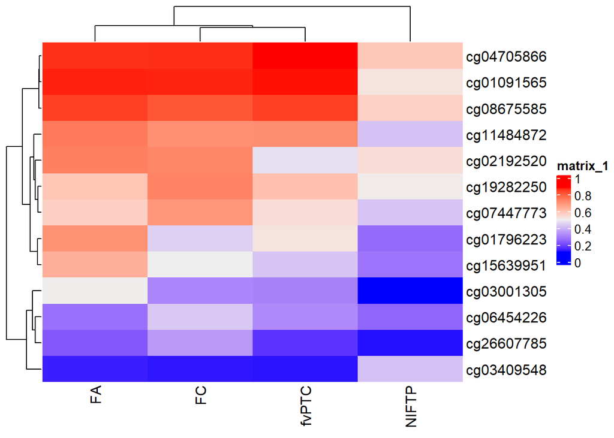

```r
# Draw basic Heatmap
Heatmap(mat)
```

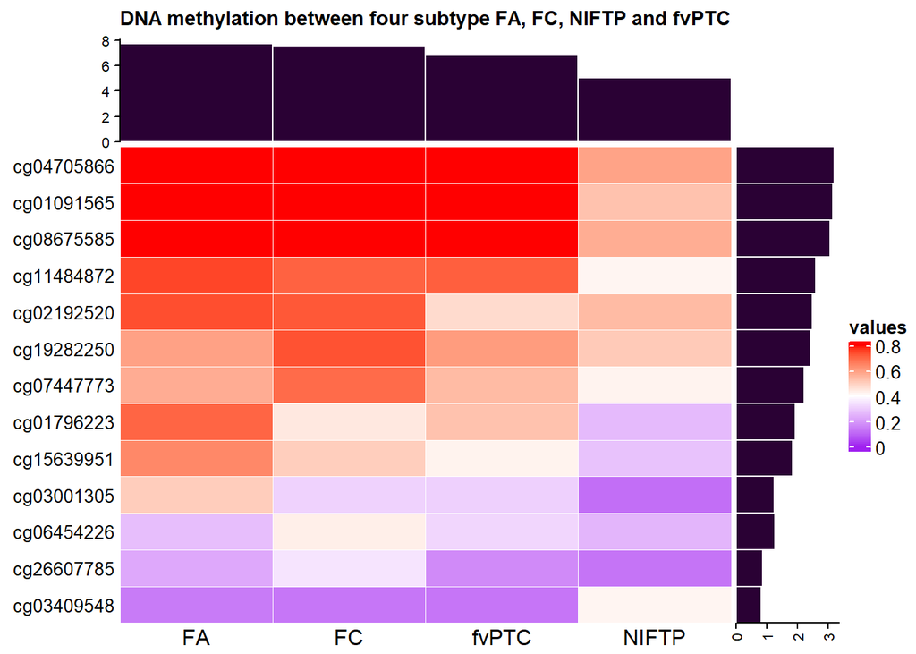

```r
# Create annotation color
col_fun = colorRamp2(c(0, 0.4, 0.8), c("purple", "white", "red"))

# create annotation for column
column_ha = HeatmapAnnotation(
    dist1 = anno_barplot(
    colSums(mat),
    bar_width = 1,
    gp = gpar(col = "white", fill = "#2a0134"),
    border = FALSE,
    axis_param = list(at = c(0, 2, 4, 6, 8), labels = c("0", "2", "4", "6", "8")),
    height = unit(2, "cm")),
    show_annotation_name = FALSE)

# create annotation for row
row_ha = rowAnnotation(
     dist2 = anno_barplot(
    rowSums(mat),
    bar_width = 1,
    gp = gpar(col = "white", fill = "#2a0134"),
    border = FALSE,
    axis_param = list(at = c(0, 1, 2, 3), labels = c("0", "1", "2", "3")),
    width = unit(2, "cm")),
    show_annotation_name = FALSE)

# deal with column variables
sub_type = colnames(mat)
ha_column = HeatmapAnnotation(
  subtype = anno_text(sub_type, rot = 0, location = unit(1, "npc"), just = "top"))

# Draw plot
ht_list = Heatmap(mat,
        name = "values", # Legend
        col = col_fun, # Generate the color mapping function
        cluster_columns = FALSE, #  Turn off row clustering
        show_row_dend = FALSE, # Hide column dendrogram
        rect_gp = gpar(col = "white", lwd = 0.1), # Set cell borders
        show_column_names = FALSE,
        row_names_side = "left",
        row_names_gp = gpar(fontsize = 10),
        column_title = 'DNA methylation between four subtype FA, FC, NIFTP and fvPTC',
        column_title_gp = gpar(fontsize = 11, fontface = "bold", hjust = 0.5),
        top_annotation = column_ha,
        bottom_annotation = ha_column,
        heatmap_legend_param = list(at = c(0, 0.2, 0.4, 0.6, 0.8),
                  labels = c("0", "0.2", "0.4", "0.6", "0.8"))) + row_ha
draw(ht_list, ht_gap = unit(1, "mm"))
```

## 2. DATA “STUDENTS’ PERFORMANCE”

### Prepare data

```r
# Load data
csv_files <- read_csv("C:/Users/lucia/Downloads/Lecturer from Dr. Loi/NGS3/NGS3-W9-19-03-2023/Data/Basic R5_ ggplot2 package/StudentsPerformance.csv")
# Convert the tibble into a data frame
data_csv <- as.data.frame(csv_files)

# Check data
head(data_csv)
```

```
##   gender race/ethnicity parental level of education        lunch
## 1 female        group B           bachelor's degree     standard
## 2 female        group C                some college     standard
## 3 female        group B             master's degree     standard
## 4   male        group A          associate's degree free/reduced
## 5   male        group C                some college     standard
## 6 female        group B          associate's degree     standard
##   test preparation course math score reading score writing score
## 1                    none         72            72            74
## 2               completed         69            90            88
## 3                    none         90            95            93
## 4                    none         47            57            44
## 5                    none         76            78            75
## 6                    none         71            83            78
```

```r
dim(data_csv)
```

```
## [1] 1000    8
```

```r
str(data_csv)
```

```
## 'data.frame':    1000 obs. of  8 variables:
##  $ gender                     : chr  "female" "female" "female" "male" ...
##  $ race/ethnicity             : chr  "group B" "group C" "group B" "group A" ...
##  $ parental level of education: chr  "bachelor's degree" "some college" "master's degree" "associate's degree" ...
##  $ lunch                      : chr  "standard" "standard" "standard" "free/reduced" ...
##  $ test preparation course    : chr  "none" "completed" "none" "none" ...
##  $ math score                 : num  72 69 90 47 76 71 88 40 64 38 ...
##  $ reading score              : num  72 90 95 57 78 83 95 43 64 60 ...
##  $ writing score              : num  74 88 93 44 75 78 92 39 67 50 ...
```

```r
# Check and remove NA
colSums(is.na(data_csv))
```

```
##                      gender              race/ethnicity
##                           0                           0
## parental level of education                       lunch
##                           0                           0
##     test preparation course                  math score
##                           0                           0
##               reading score               writing score
##                           0                           0
```

```r
data_rm_data2 <- na.omit(data_csv)
head(data_csv)
```

```
##   gender race/ethnicity parental level of education        lunch
## 1 female        group B           bachelor's degree     standard
## 2 female        group C                some college     standard
## 3 female        group B             master's degree     standard
## 4   male        group A          associate's degree free/reduced
## 5   male        group C                some college     standard
## 6 female        group B          associate's degree     standard
##   test preparation course math score reading score writing score
## 1                    none         72            72            74
## 2               completed         69            90            88
## 3                    none         90            95            93
## 4                    none         47            57            44
## 5                    none         76            78            75
## 6                    none         71            83            78
```

### 2.1 Plot PCA:

```r
# Numeric data
number_data2 <- data_rm_data2[,6:8]
head(number_data2)
```

```
##   math score reading score writing score
## 1         72            72            74
## 2         69            90            88
## 3         90            95            93
## 4         47            57            44
## 5         76            78            75
## 6         71            83            78
```

```r
str(number_data2)
```

```
## 'data.frame':    1000 obs. of  3 variables:
##  $ math score   : num  72 69 90 47 76 71 88 40 64 38 ...
##  $ reading score: num  72 90 95 57 78 83 95 43 64 60 ...
##  $ writing score: num  74 88 93 44 75 78 92 39 67 50 ...
```

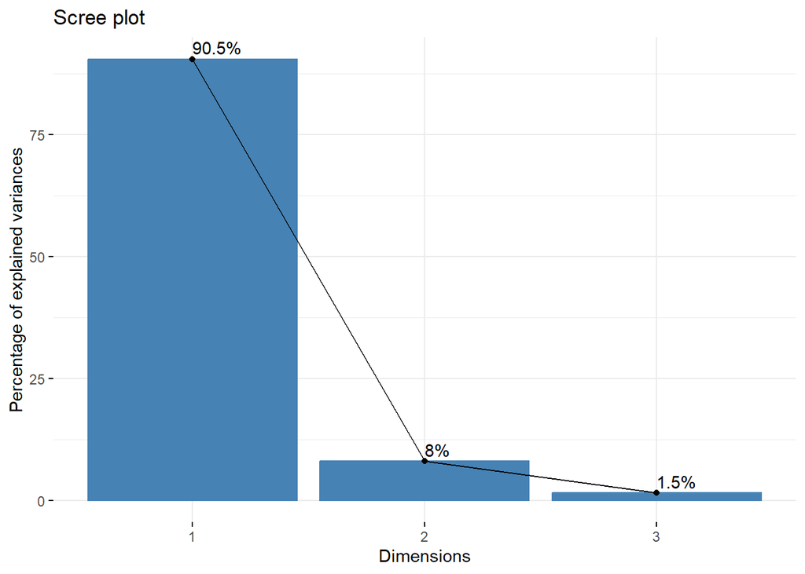

```r
# Caculate PCA
Xpca_data2 <- prcomp(number_data2)
fviz_eig(Xpca_data2, addlabels=TRUE, ncp=20)
```

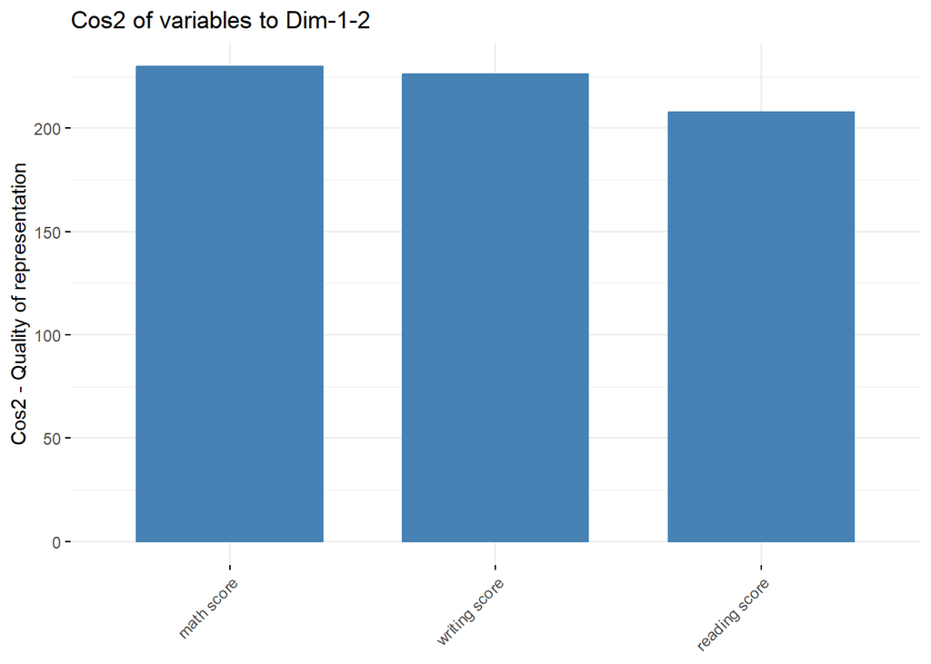

```r
fviz_cos2(Xpca_data2, choice = "var", axes = 1:2)
```

```r
# Draw PCA
data_PCA_data2 <- as.data.frame(Xpca_data2$x)
head(data_PCA_data2)
```

```
##          PC1       PC2       PC3
## 1  -8.488375 -1.264120  2.158445
## 2 -25.461441 13.731177 -1.848563
## 3 -43.121753  0.359506 -1.290175
## 4  32.036284  0.878501 -7.998383
## 5 -14.777792 -2.006871 -1.432037
## 6 -16.619309  5.207478 -3.319360
```

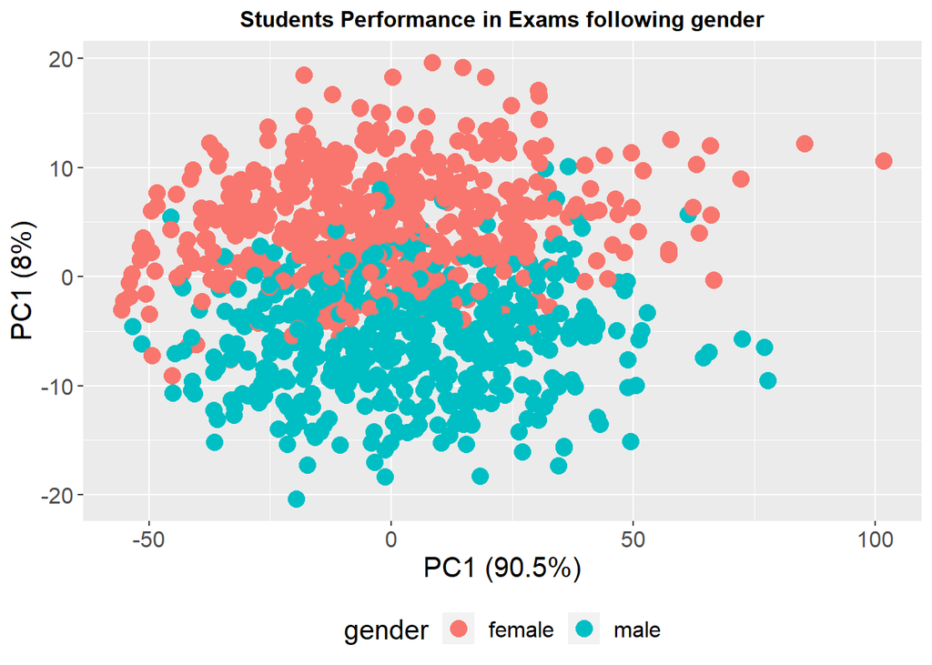

```r
## Plot PCA following gender:
data_PCA_data2$gender <- data_rm_data2$gender
ggplot(data_PCA_data2, aes(x = PC1, y = PC2, col=gender)) + geom_point(size=4, alpha=2) + theme(legend.position="bottom") + theme(text = element_text(size = 15))+ labs(x="PC1 (90.5%)", y="PC1 (8%)", title="Students Performance in Exams following gender") +
  theme(plot.title = element_text(face="bold",size=12, hjust =0.5))
```

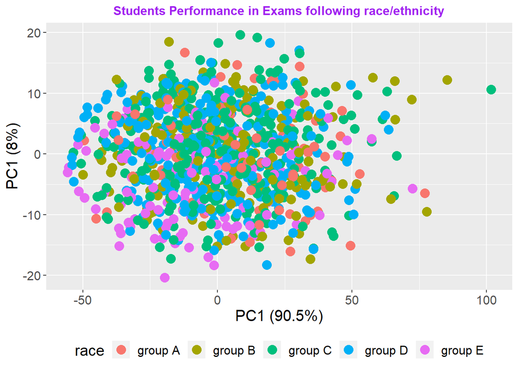

```r
## Plot PCA following race/ethnicity:
data_PCA_data2$race <- data_rm_data2$`race/ethnicity`
ggplot(data_PCA_data2, aes(x = PC1, y = PC2, col=race)) + geom_point(size=4, alpha=2) + theme(legend.position="bottom") + theme(text = element_text(size = 15))+ labs(x="PC1 (90.5%)", y="PC1 (8%)", title="Students Performance in Exams following race/ethnicity") +
  theme(plot.title = element_text(face="bold",size=12, hjust =0.5, colour = "purple"))
```

### 2.2 Plot heat:

```r
# Plot heat following gender
data_melt <- melt(data_rm_data2)
head(data_melt)
```

```
##   gender race/ethnicity parental level of education        lunch
## 1 female        group B           bachelor's degree     standard
## 2 female        group C                some college     standard
## 3 female        group B             master's degree     standard
## 4   male        group A          associate's degree free/reduced
## 5   male        group C                some college     standard
## 6 female        group B          associate's degree     standard
##   test preparation course   variable value
## 1                    none math score    72
## 2               completed math score    69
## 3                    none math score    90
## 4                    none math score    47
## 5                    none math score    76
## 6                    none math score    71
```

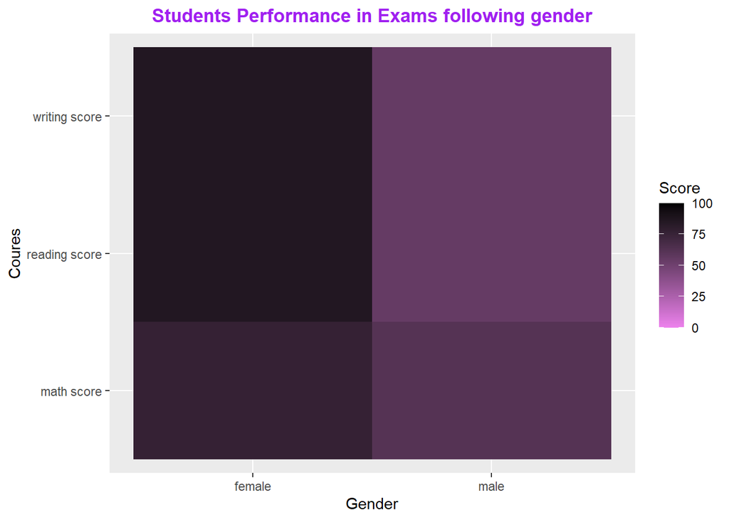

```r
ggp <- ggplot(data_melt, aes(gender, variable)) +# Create heatmap with ggplot2
  geom_tile(aes(fill = value)) +
  labs(title="Students Performance in Exams following gender",
       y="Coures",
       x="Gender",
       fill="Score") + # Name of legend
  theme_set(theme_classic()) +
  theme(plot.title = element_text(face="bold",size=13, hjust =0.5, colour = "purple"))

ggp + scale_fill_gradient(low = "violet", high = "black")
```

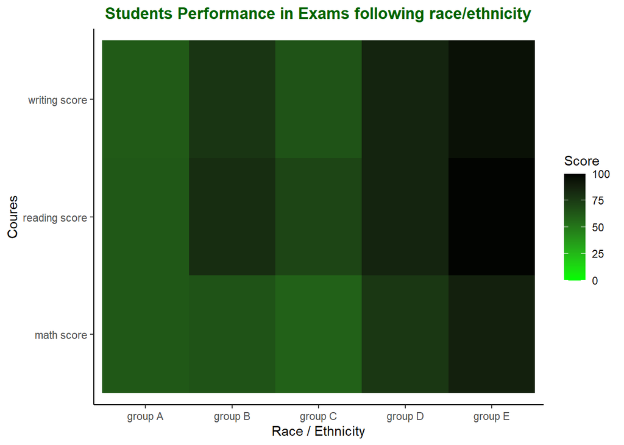

```r
# Plot heat following race/ethnicity
ggp <- ggplot(data_melt, aes(`race/ethnicity`, variable)) +# Create heatmap with ggplot2
  geom_tile(aes(fill = value)) +
  labs(title="Students Performance in Exams following race/ethnicity",
       y="Coures",
       x="Race / Ethnicity",
       fill="Score") + # Name of legend
  theme_set(theme_classic()) +
  theme(plot.title = element_text(face="bold",size=13, hjust =0.5, colour = "darkgreen"))
ggp + scale_fill_gradient(low = "green", high = "black")
```